# Assignment 2, Part C

From my analysis major roadworks done in the ACT should be conducted from spring to early autumn, ideally during late spring throughout summer as this is when temperatures for curing concrete are ideal and workers can avoid frost and such. However, over the last 4-5 years the average rainfall has been steadily increasing (especially during the recommended months), so roadworks will have to be planned around upcoming weather as, rain can wash away progress or affect the structure of the road. Regarding planning around potholes, the heaviest rain season appears to be spring and late winter. Therefore the best opportunities for major pothole filling come in summer and autumn where the average rainfall is lower and temps are high allowing the asphalt to cure. Note, by fixing potholes in a timely manner throughout the entire in dry conditions you can prevent further rain and vehicles from increasing the damage to the road making the repaving procedure more complex and costly, as well as having to wait for the more ideal repair seasons.

3. As a data scientist, you need to practice extracting insights and valuable information from the analysis you conduct on the data. This can be done by posing some real-world problems or decisions that can be solved by doing some analysis on this data. For this task list at least **2 (two)** problems that can be solved by running analysis on this data set, if you are undergraduate student. Otherwise, generate at least **4 (four)** problems that can be solved by running analysis on this data set. (5 marks)

**Solution**

**Decision/Problem_1** In horticulture: Is it commercially viable to grow grapes for wine production in the ACT? If so what weather factors do farmers have to keep an eye on?

**Knowledge** “grapes flower in spring, producing their crop throughout summer”[How to grow and prune grapevines - bunnings Australia (no date) Bunnings Australia. Available at: https://www.bunnings.com.au/diy-advice/garden/planting-and-growing/how-to-grow-and-care-for-grapevines (Accessed: 13 October 2023).] “The overall optimum temperature grapevine growth is 77 and 90 degrees F (25 to 32°C). Any temperature below this optimum range causes vegetative growth to become limited. Warmer temperatures in general tend to produce more consistent grape harvests. Lack of rainfall can be a severe influence on grape productivity in the absence of good quality irrigation water. Johnson and Robinson (2001) recommend a minimum level of rainfall/irrigation of 20 inches (500 mm), higher if the growing season is characterized by high evapotranspiration rates. Excess rainfall is also a problem and most quality wines are produced in regions where annual rainfall does not exceed 28 to 32 inches (700 to 800 mm) (Jackson et al., 1987). Wind - Light breezes maintain air circulation around the berries stopping the buildup of humidity and maintaining an even temperature within the canopy. However, high winds can cause serious damage to grapevines, especially to vines in the spring and early summer, when shoots are tender and more easily broken.” [Vineyard site selection (no date) Grape Grower’s Handbook: A Guide To Viticulture for Wine Production. Available at: https://www.wine-grape-growing.com/wine_grape_growing/vineyard_site_selection/vineyard_site_selection_climatic_components.htm (Accessed: 13 October 2023).]

**Information Needed** Average temperature throughout spring and Summer, average yearly rainfall, average wind speed seasonally.

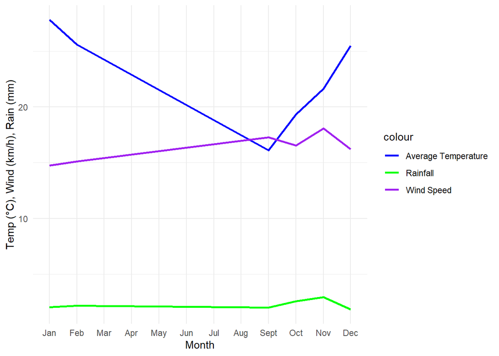

```r
spring_summer_data <- act_weather_data %>%
  filter(Month %in% c("9", "10", "11", "12", "1", "2")) %>%  # Spring and Summer months
  group_by(Month) %>%
  summarize(
    Avg_Temperature = mean((`3pm_Temperature`)),
    Avg_Rainfall = mean(`Rainfall_(mm)`),
    Avg_Wind_Speed = mean((`9am_wind_speed_(km/h)` + `3pm_wind_speed_(km/h)`) / 2)
  )

ggplot(spring_summer_data, aes(x = Month)) +
  geom_line(aes(y = Avg_Temperature, color = "Average Temperature"), size = 1) +
  geom_line(aes(y = Avg_Rainfall, color = "Rainfall"), size = 1) +
  geom_line(aes(y = Avg_Wind_Speed, color = "Wind Speed"), size = 1) +
  labs(
    x = "Month",
    y = "Temp (°C), Wind (km/h), Rain (mm)",
  ) +
  scale_x_discrete(limits = month_order) +
  scale_color_manual(values = c("Average Temperature" = "blue", "Rainfall" = "green", "Wind Speed" = "purple")) +
  theme_minimal()
```

```r
yearly_rainfall <- act_weather_data %>%
  filter(Year != 2023, Year != 2018) %>%
  group_by(Year) %>%
  summarize(
    Total_Rainfall = sum(`Rainfall_(mm)`)
  )

print(yearly_rainfall)
```

```
## # A tibble: 4 × 2
##    Year Total_Rainfall
##   <dbl>          <dbl>
## 1  2019           359.
## 2  2020           544.
## 3  2021           916
## 4  2022           892.
```

```r
mean_yearly_rainfall <- mean(yearly_rainfall$Total_Rainfall)
print(mean_yearly_rainfall)
```

```
## [1] 677.65
```

**Decision/Problem_2** In horticulture: Can rice be grown commercially in the ACT? If so when is the best season for planting?

**Knowledge** “Originally from tropical regions, rice is a warm-season crop that requires constant heat and humidity to grow. It can be cultivated as an annual in warm climates, though, even if you don’t reside in the tropics. During the growing season, the best temperature for rice is between 70°F and 99°F (21°C and 37°C). It is possible to grow it only where nighttime lows stay at 60°F (15°C) or higher for a minimum of three months annually. How come it’s so important? Germination is temperature-dependent, so the lows for the growing crop must always be above that mark. The water needs of growing rice far exceed those of any other crop. Thus, only in locations with a minimum annual rainfall of 45 inches (115 cm) does rice growing take place. The best growing conditions can be found in areas where yearly rainfall is between 69 and 118 inches (175 and 300 cm) on average. Paddies must be inundated for at least 10 weeks during the growing season, with water depths ranging from 1 inch (25 mm) at the transplanting stage to as much as 6 inches (150 mm) throughout the crop life cycle.” [Kogut, P. (2023) How to grow rice: Planting, care, & harvesting practices, EOS Data Analytics. Available at: https://eos.com/blog/how-to-grow-rice/ (Accessed: 14 October 2023). ] “Humidity should range somewhere from 60 - 85%.” [De Silva, R. and Dayawansa, N.D.K. (2016) Assessment of the suitability of temperature and relative humidity for rice cultivation in rainfed lowland paddy fields in Kurunegala district, Research Gate. Available at: https://www.researchgate.net/publication/319227475_Assessment_of_the_suitability_of_temperature_and_relative_humidity_for_rice_cultivation_in_rainfed_lowland_paddy_fields_in_Kurunegala_district (Accessed: 13 October 2023).]

**Information Needed** Monthly average heat and humidity chart, monthly low temperature average, Annual Rainfall and average rainfall across months charted.

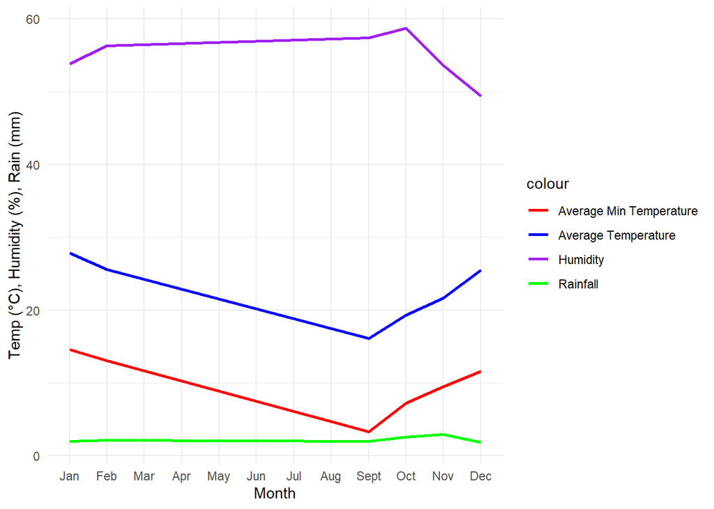

```r
spring_summer_data_2 <- act_weather_data %>%
  filter(Month %in% c("9", "10", "11", "12", "1", "2")) %>%  # Spring and Summer months
  group_by(Month) %>%
  summarize(
    Avg_Min_Temp = mean(`Minimum_temperature`),
    Avg_Temperature = mean((`3pm_Temperature`)),
    Avg_Rainfall = mean(`Rainfall_(mm)`),
    Avg_Humidity = mean((`9am_relative_humidity_(%)` + `3pm_relative_humidity_(%)`) / 2),
    )

ggplot(spring_summer_data_2, aes(x = Month)) +
  geom_line(aes(y = Avg_Min_Temp, color = "Average Min Temperature"), size = 1) +
  geom_line(aes(y = Avg_Temperature, color = "Average Temperature"), size = 1) +
  geom_line(aes(y = Avg_Rainfall, color = "Rainfall"), size = 1) +
  geom_line(aes(y = Avg_Humidity, color = "Humidity"), size = 1) +
  labs(
    x = "Month",
    y = "Temp (°C), Humidity (%), Rain (mm)",
  ) +
  scale_x_discrete(limits = month_order) +
  scale_color_manual(values = c("Average Min Temperature" = "red", "Average Temperature" = "blue", "Rainfall" = "green", "Humidity" = "purple")) +
  theme_minimal()
```

```r
yearly_rainfall <- act_weather_data %>%
  filter(Year != 2023, Year != 2018) %>%
  group_by(Year) %>%
  summarize(
    Total_Rainfall = sum(`Rainfall_(mm)`)
  )

print(yearly_rainfall)
```

```
## # A tibble: 4 × 2
##    Year Total_Rainfall
##   <dbl>          <dbl>
## 1  2019           359.
## 2  2020           544.
## 3  2021           916
## 4  2022           892.
```

```r
mean_yearly_rainfall <- mean(yearly_rainfall$Total_Rainfall)
print(mean_yearly_rainfall)
```

```
## [1] 677.65
```